# Final Project

Alejandro D. Osborne

July 18, 2019

# In This project I’m going to look build a system that can recommend beer to a user based on the ratings they’ve provided. Before we can get to that however, we need to evaluate the very large data set we will be working with.

```r
library(kableExtra)
library(dplyr)
library(tidyr)
library(recommenderlab)
library(knitr)
library(sparklyr)
```

```r
library(plotly)
library(DT)
beer = read.csv("https://raw.githubusercontent.com/AlejandroOsborne/DATA612/master/beer_reviews.csv", )
```

```r
head(beer) %>% kable("html") %>% kable_styling()
```

| review | user | beerid |
| --- | --- | --- |
| 1.5 | stcules | 47986 |
| 3.0 | stcules | 48213 |
| 3.0 | stcules | 48215 |
| 3.0 | stcules | 47969 |
| 4.0 | johnmichaelsen | 64883 |
| 3.0 | oline73 | 52159 |

## The dataset contains 3 attributes Beer Id, User & Overall Review Rating given by reviewer. In total 1000000 reviews are given.

```r
str(beer)
```

```
## 'data.frame':    1000000 obs. of  3 variables:
##  $ review: num  1.5 3 3 3 4 3 3.5 3 4 4.5 ...
##  $ user  : Factor w/ 28245 levels "","0110x011",..: 24172 24172 24172 24172 13791 19380 21322 878 15908 1480 ...
##  $ beerid: int  47986 48213 48215 47969 64883 52159 52159 52159 52159 52159 ...
```

```r
summary(beer)
```

```
##      review                  user            beerid
##  Min.   :0.000   northyorksammy:  3510   Min.   :    3
##  1st Qu.:3.500   mikesgroove   :  2983   1st Qu.: 1934
##  Median :4.000   BuckeyeNation :  2763   Median :16506
##  Mean   :3.835   womencantsail :  2308   Mean   :22850
##  3rd Qu.:4.500   ChainGangGuy  :  2236   3rd Qu.:41195
##  Max.   :5.000   Thorpe429     :  2212   Max.   :77316
##                  (Other)       :983988
```

### I want to find the empty entries

```r
nrow(beer[(is.na(beer$user) | beer$user==""), ])
```

```
## [1] 219
```

### Removing empty

```r
beer<-beer[!(beer$user==""), ]
```

### Checking for duplicates where both item and user are duplicated or same user gave multiple ratings to same beer.

```r
beer[!(duplicated(beer[c("beerid","user")]) | duplicated(beer[c("beerid","user")], fromLast = TRUE)), ] %>% nrow()
```

```
## [1] 981601
```

```r
beer %>% distinct(beerid,user,.keep_all = TRUE) %>% nrow()
```

```
## [1] 990539
```

### There are 990539 distict reviews

### Removing duplicates having both beer & user duplicated, this will ensure that no 2 reviews from single user to same beer are counted & cumulate.

```r
beer<-distinct(beer,beerid,user,.keep_all = TRUE)
```

## Data Preparation

### Choose only those beers that have at least N number of reviews

```r
beer_reviews_count <- beer %>% group_by(beerid) %>% summarise(total_beer_reviews=n())
dim(beer_reviews_count)
```

```
## [1] 39880     2
```

### Total 39880 distinct beers.

### Sorting beers by reviews

```r
beer_reviews_count[with(beer_reviews_count, order(total_beer_reviews,decreasing = TRUE)), ]
```

| beerid | total_beer_reviews |
| --- | --- |
| 1904 | 2929 |
| 4083 | 2644 |
| 92 | 2633 |
| 1093 | 2631 |
| 88 | 2526 |
| 276 | 2526 |
| 34 | 2480 |
| 695 | 2448 |
| 2671 | 2443 |
| 11757 | 2443 |

[output cut: 9990 more lines]

```r
summary(beer_reviews_count)
```

```
##      beerid      total_beer_reviews
##  Min.   :    3   Min.   :   1.00
##  1st Qu.:20965   1st Qu.:   1.00
##  Median :41423   Median :   2.00
##  Mean   :40232   Mean   :  24.84
##  3rd Qu.:59881   3rd Qu.:   7.00
##  Max.   :77316   Max.   :2929.00
```

### Beers have reviews count in range of 1 to 2929, beer 1904 has the highest number of reviews with 2,929.

### Now we want to know the number of distinct users:

```r
beer %>% group_by(user) %>% summarise(total_user_reviews=n()) %>% nrow()
```

```
## [1] 28244
```

### 28244 distinct users

### Now we want to know which users have reviewed maximum beers

```r
beer %>% group_by(user) %>% summarise(user_review_count=n()) %>% top_n(1)
```

| user | user_review_count |
| --- | --- |
| northyorksammy | 3487 |

### User: northyorksammy has reviewed the most beers

### To find an ideal value of N its important that we choose beers having large enough number of reviews to avoid cold start problem.

### So Lets further analyze beers by number of reviews each one have received. lets start with all beers with single review.

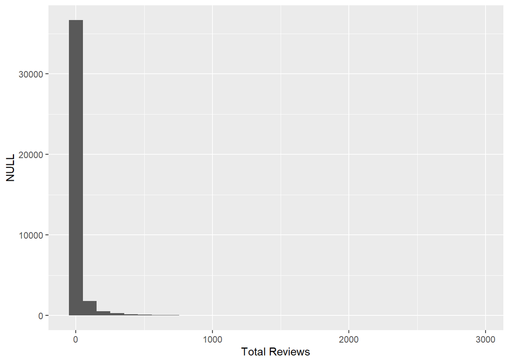

```r
qplot(beer_reviews_count$total_beer_reviews, geom = "histogram",xlab="Total Reviews")
```

```r
beer_reviews_count %>% subset(total_beer_reviews==1) %>% dim()
```

```
## [1] 14275     2
```

### 14,275 beers have only 1 review, right now lets group by total reviews & find count for each.

### Lets create separate dataframe with frequency of count of reviews

```r
review_frequency<-beer_reviews_count %>% group_by(total_beer_reviews) %>% summarise(review_occurance=n())

head(review_frequency,25)
```

| total_beer_reviews | review_occurance |
| --- | --- |
| 1 | 14275 |
| 2 | 6354 |
| 3 | 3463 |
| 4 | 2246 |
| 5 | 1591 |
| 6 | 1134 |
| 7 | 883 |
| 8 | 728 |
| 9 | 570 |
| 10 | 502 |

[output cut: 15 more lines]

### It seems that most beers get very few reviews. In fact very few beers have large enough number of reviews required for building recommendation system based on collaborative filtering.

### Filtering by beers having atleast 50 reviews & users having reviewed atleast 30 beers as there are more distinct beers.

```r
beer_reviews_count_subset<-subset(beer_reviews_count,beer_reviews_count$total_beer_reviews>=50)
```

### Now we are left with a dataset of these distinct beer ids each having more than 50 reviews each.

### Now, lets check beer review frequency

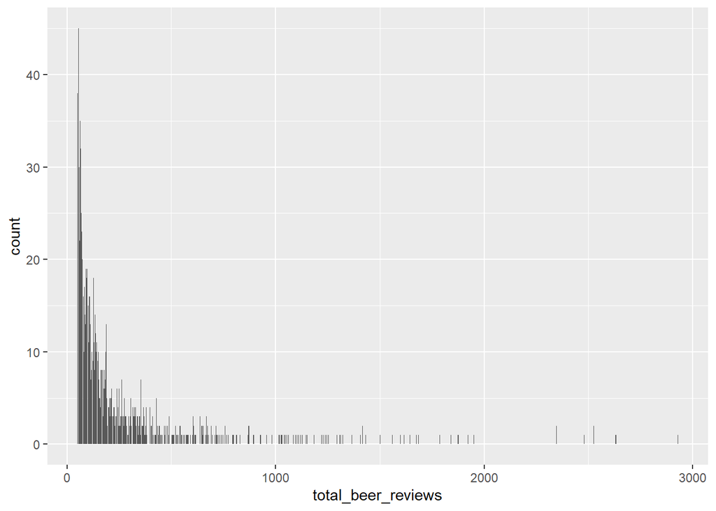

```r
ggplot(beer_reviews_count_subset,aes(x=total_beer_reviews)) + geom_bar()
```

### Lets also filter beer dataset based on users who have atleast reviewed 30 beers each

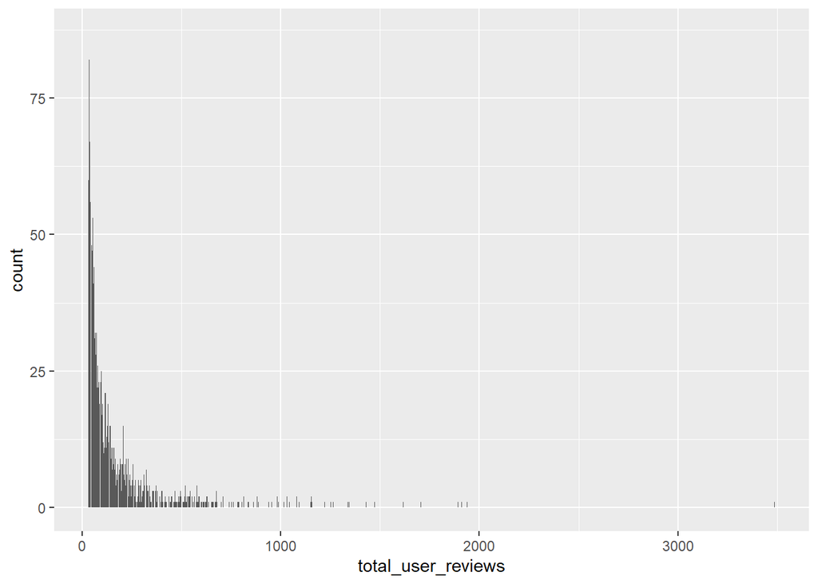

```r
user_reviews_count<- beer %>% group_by(user) %>% summarise(total_user_reviews=n())
user_reviews_count_subset<-subset(user_reviews_count,user_reviews_count$total_user_reviews>=30)
ggplot(user_reviews_count_subset,aes(x=total_user_reviews)) + geom_bar()
```

### Now lets filter original data by these beer and user ids

```r
important_beers<-merge(beer,beer_reviews_count_subset,by.x="beerid",by.y="beerid")
important_beers<-merge(important_beers,user_reviews_count_subset,by.x="user",by.y="user")

summary(important_beers)
```

```
##              user            beerid          review
##  BuckeyeNation :  1977   Min.   :    5   Min.   :1.000
##  mikesgroove   :  1956   1st Qu.: 1576   1st Qu.:3.500
##  northyorksammy:  1694   Median :10317   Median :4.000
##  brentk56      :  1589   Mean   :20070   Mean   :3.861
##  ChainGangGuy  :  1502   3rd Qu.:37691   3rd Qu.:4.500
##  WesWes        :  1469   Max.   :76816   Max.   :5.000
##  (Other)       :688101
##  total_beer_reviews total_user_reviews
##  Min.   :  50.0     Min.   :  30.0
##  1st Qu.: 182.0     1st Qu.: 134.0
##  Median : 411.0     Median : 304.0
##  Mean   : 631.5     Mean   : 480.6
##  3rd Qu.: 871.0     3rd Qu.: 628.0
##  Max.   :2929.0     Max.   :3487.0
##
```

### Now we’ll need to Convert this data frame to a “realratingMatrix” before we build out our collaborative filtering models

```r
beers_rrmatrix <- as(important_beers[,c(1,2,3)], "realRatingMatrix")
class(beers_rrmatrix)
```

```
## [1] "realRatingMatrix"
## attr(,"package")
## [1] "recommenderlab"
```

### Converting the matrix to a dataframe

```r
beers_df <- as(beers_rrmatrix, "data.frame")
str(beers_df)
```

```
## 'data.frame':    698288 obs. of  3 variables:
##  $ user  : Factor w/ 4902 levels "0110x011","05Harley",..: 1 1 1 1 1 1 1 1 1 1 ...
##  $ item  : Factor w/ 3235 levels "100","1000","10002",..: 2592 2983 48 75 210 276 280 372 438 776 ...
##  $ rating: num  4 5 4 4 4 4 5 2 5 5 ...
```

```r
summary(beers_df)
```

```
##              user             item            rating
##  BuckeyeNation :  1977   1904   :  2305   Min.   :1.000
##  mikesgroove   :  1956   1093   :  2063   1st Qu.:3.500
##  northyorksammy:  1694   4083   :  2046   Median :4.000
##  brentk56      :  1589   2671   :  2000   Mean   :3.861
##  ChainGangGuy  :  1502   92     :  1996   3rd Qu.:4.500
##  WesWes        :  1469   88     :  1976   Max.   :5.000
##  (Other)       :688101   (Other):685902
```

### Data Exploration:

### Determine how similar the first ten users are with each other and visualize it

```r
similar_users <- similarity(beers_rrmatrix[1:10,],method = "cosine",which = "users")
kable(as.matrix(similar_users))
```

|  | 0110x011 | 05Harley | 100floods | 11osixBrew | 1759Girl | 1Adam12 | 1fastz28 | 1morebeer | 1whiskey | 2xHops |
| --- | --- | --- | --- | --- | --- | --- | --- | --- | --- | --- |
| 0110x011 | 0.0000000 | 0.9910902 | 0.9853619 | 0.9982744 | 0.9744681 | 0.9861836 | 0.9832757 | 1.0000000 | 0.9374253 | 0.9967225 |
| 05Harley | 0.9910902 | 0.0000000 | 0.9897318 | 0.9941348 | 0.9938837 | 0.9782111 | 0.9897082 | 0.9986178 | 0.9856839 | 0.9953785 |
| 100floods | 0.9853619 | 0.9897318 | 0.0000000 | 0.9983101 | 0.9703235 | 0.9952494 | 0.9915450 | NA | 0.9867474 | 0.9941934 |
| 11osixBrew | 0.9982744 | 0.9941348 | 0.9983101 | 0.0000000 | 0.9902823 | 1.0000000 | 0.9903797 | 0.9982744 | NA | 1.0000000 |
| 1759Girl | 0.9744681 | 0.9938837 | 0.9703235 | 0.9902823 | 0.0000000 | 0.9982744 | 0.9701085 | 0.9788487 | 0.9585606 | 0.9979652 |
| 1Adam12 | 0.9861836 | 0.9782111 | 0.9952494 | 1.0000000 | 0.9982744 | 0.0000000 | 0.9798434 | 0.9858652 | 0.9955451 | 0.9920178 |
| 1fastz28 | 0.9832757 | 0.9897082 | 0.9915450 | 0.9903797 | 0.9701085 | 0.9798434 | 0.0000000 | 0.9909244 | 0.9831871 | 0.9954419 |
| 1morebeer | 1.0000000 | 0.9986178 | NA | 0.9982744 | 0.9788487 | 0.9858652 | 0.9909244 | 0.0000000 | 1.0000000 | 0.9987300 |
| 1whiskey | 0.9374253 | 0.9856839 | 0.9867474 | NA | 0.9585606 | 0.9955451 | 0.9831871 | 1.0000000 | 0.0000000 | 1.0000000 |
| 2xHops | 0.9967225 | 0.9953785 | 0.9941934 | 1.0000000 | 0.9979652 | 0.9920178 | 0.9954419 | 0.9987300 | 1.0000000 | 0.0000000 |

### Visualising similarity matrix

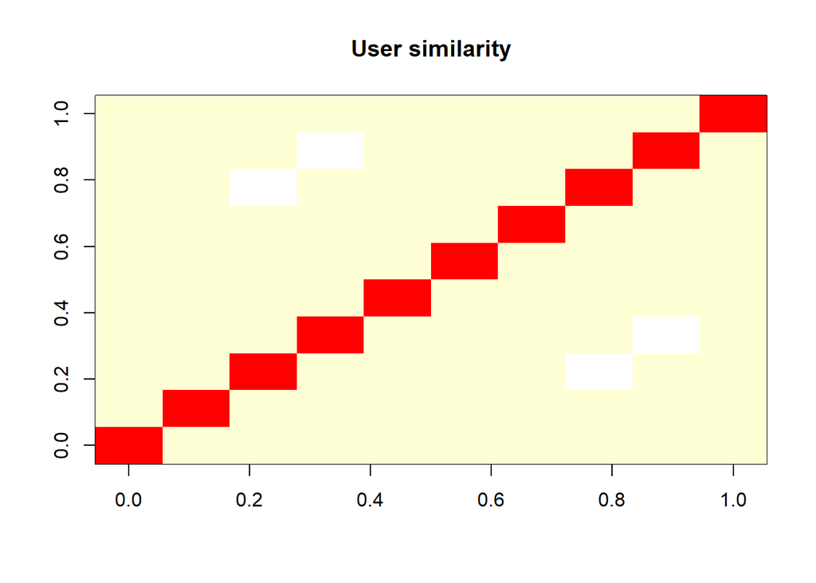

```r
image(as.matrix(similar_users), main = "User similarity")
```

### No we’ll Compute and visualize the similarity between the first 10 beers

### How similar are the first ten beers are with each other?

```r
similar_beers <- similarity(beers_rrmatrix[,1:10],method = "cosine",which = "items")
kable(as.matrix(similar_beers))
```

|  | 5 | 6 | 7 | 8 | 9 | 11 | 12 | 13 | 17 | 29 |
| --- | --- | --- | --- | --- | --- | --- | --- | --- | --- | --- |
| 5 | 0.0000000 | 0.9789667 | 0.9701730 | 0.9727385 | 0.9765296 | 0.9577282 | 0.9668768 | 0.9563776 | 0.9672323 | 0.9718821 |
| 6 | 0.9789667 | 0.0000000 | 0.9699214 | 0.9590428 | 0.9677080 | 0.9696973 | 0.9782380 | 0.9658235 | 0.9716618 | 0.9649160 |
| 7 | 0.9701730 | 0.9699214 | 0.0000000 | 0.9612631 | 0.9633289 | 0.9626611 | 0.9553550 | 0.9622305 | 0.9478337 | 0.9523921 |
| 8 | 0.9727385 | 0.9590428 | 0.9612631 | 0.0000000 | 0.9791632 | 0.9876651 | 0.9916805 | 0.9415863 | 0.9676003 | 0.9764641 |
| 9 | 0.9765296 | 0.9677080 | 0.9633289 | 0.9791632 | 0.0000000 | 0.9468143 | 0.9573247 | 0.9373387 | 0.9527440 | 0.9596972 |
| 11 | 0.9577282 | 0.9696973 | 0.9626611 | 0.9876651 | 0.9468143 | 0.0000000 | 0.9723262 | 0.9793518 | 0.9672233 | 0.9387293 |
| 12 | 0.9668768 | 0.9782380 | 0.9553550 | 0.9916805 | 0.9573247 | 0.9723262 | 0.0000000 | 0.9762209 | 0.9641185 | 0.9571352 |
| 13 | 0.9563776 | 0.9658235 | 0.9622305 | 0.9415863 | 0.9373387 | 0.9793518 | 0.9762209 | 0.0000000 | 0.9638050 | 0.9618576 |
| 17 | 0.9672323 | 0.9716618 | 0.9478337 | 0.9676003 | 0.9527440 | 0.9672233 | 0.9641185 | 0.9638050 | 0.0000000 | 0.9624879 |
| 29 | 0.9718821 | 0.9649160 | 0.9523921 | 0.9764641 | 0.9596972 | 0.9387293 | 0.9571352 | 0.9618576 | 0.9624879 | 0.0000000 |

### Beer similarity matrix

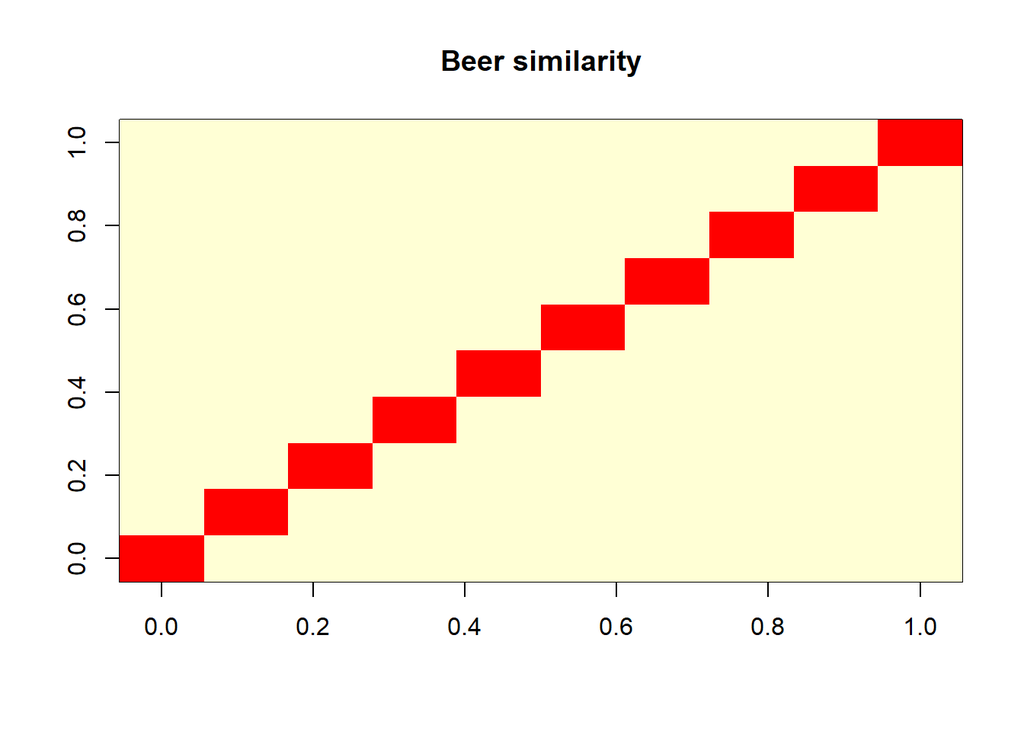

```r
image(as.matrix(similar_beers), main = "Beer similarity")
```

### What are the unique values of the ratings?

```r
beers_df %>% group_by(rating) %>% summarise(rating_frequency=n()) %>% nrow()
```

```
## [1] 9
```

### We have 9 distinct ratings, lets check frequency of each rating.

```r
beers_df %>% group_by(rating) %>% summarise(rating_frequency=n())
```

| rating | rating_frequency |
| --- | --- |
| 1.0 | 2864 |
| 1.5 | 3893 |
| 2.0 | 13005 |
| 2.5 | 21407 |
| 3.0 | 66651 |
| 3.5 | 132847 |
| 4.0 | 269669 |
| 4.5 | 150388 |
| 5.0 | 37564 |

### Rating 4.0 & 4.5 are most common, 1.0 & 1.5 are least common.

### Let’s visualize and and look at the average beer ratings

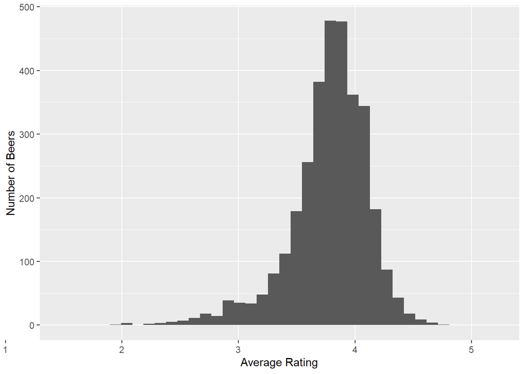

```r
avg_beer_ratings<-beers_df %>% group_by(item) %>% summarise(average_rating=mean(rating))
colors <- c(rep("red",2), rep("blue",2), rep("green",1))
ggplot(avg_beer_ratings,aes(x=average_rating)) + geom_histogram() + labs(x="Average Rating", y="Number of Beers") + scale_x_discrete(limits=1:5)
```

```r
summary(avg_beer_ratings$average_rating)
```

```
##    Min. 1st Qu.  Median    Mean 3rd Qu.    Max.
##   1.902   3.629   3.821   3.779   3.998   4.719
```

### Checking on original full dataset of beers

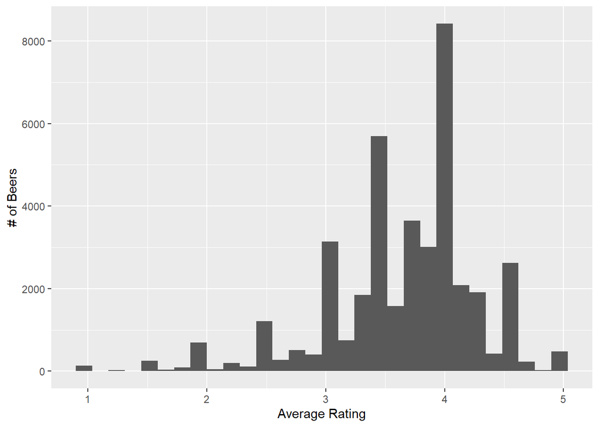

```r
avg_beer_ratings_all<-beer %>% group_by(beerid) %>% summarise(average_rating=mean(review))
ggplot(avg_beer_ratings_all,aes(x=average_rating)) + geom_histogram() + labs(x="Average Rating", y="# of Beers")
```

```r
summary(avg_beer_ratings_all$average_rating)
```

```
##    Min. 1st Qu.  Median    Mean 3rd Qu.    Max.
##   1.000   3.409   3.750   3.655   4.000   5.000
```

### So average beer ratings(Mean)=3.655 & Median=3.75, uneven distribution.

### The Average user ratings

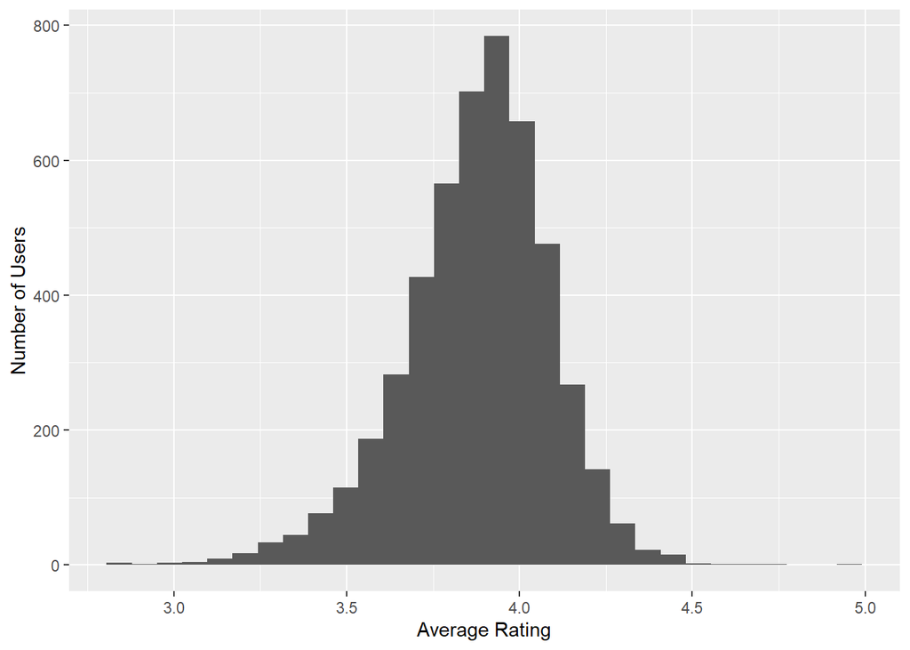

```r
avg_user_ratings<-beers_df %>% group_by(user) %>% summarise(average_rating=mean(rating))
ggplot(avg_user_ratings,aes(x=average_rating)) + geom_histogram() + labs(x="Average Rating", y="Number of Users")
```

```r
summary(avg_user_ratings$average_rating)
```

```
##    Min. 1st Qu.  Median    Mean 3rd Qu.    Max.
##   2.808   3.757   3.897   3.877   4.015   4.921
```

### The average number of ratings given to the beers

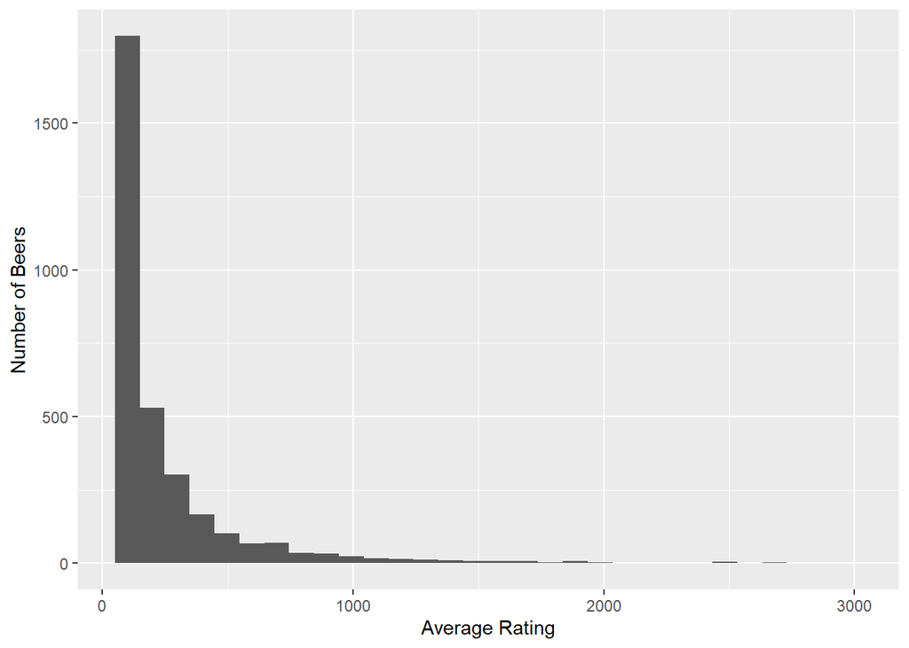

```r
avg_beer_reviews<-important_beers %>% group_by(beerid) %>% summarise(average_reviews=mean(total_beer_reviews))
ggplot(avg_beer_reviews,aes(x=average_reviews)) + geom_histogram() + labs(x="Average Rating", y="Number of Beers")
```

```r
summary(avg_beer_reviews$average_reviews)
```

```
##    Min. 1st Qu.  Median    Mean 3rd Qu.    Max.
##    50.0    75.0   129.0   246.2   277.0  2929.0
```

### So on average each beer gets ~246 reviews from chosen subset.

### Also checking on original full dataset of beers

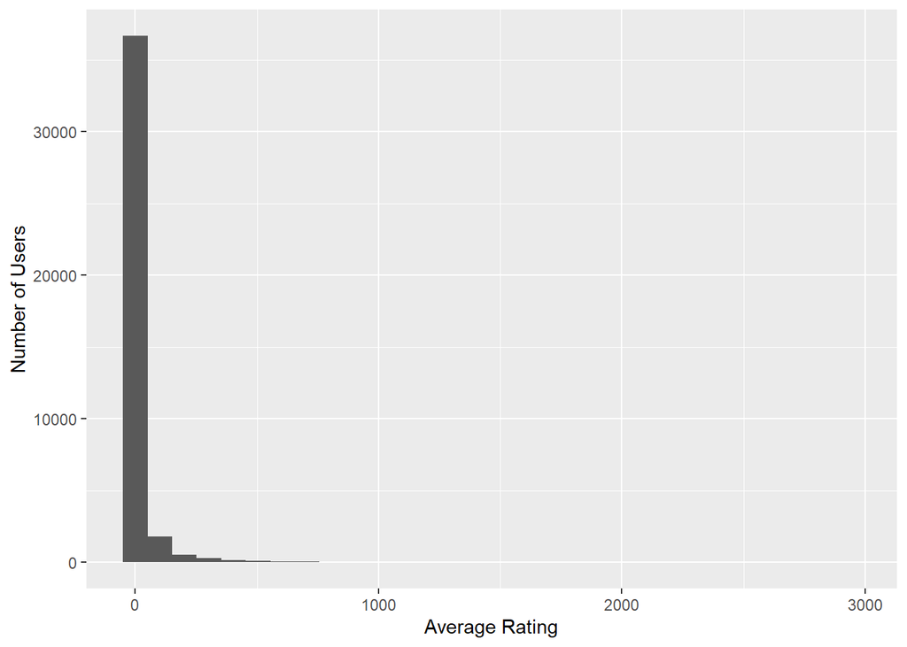

```r
avg_user_ratings_all<-beer_reviews_count %>% group_by(beerid) %>% summarise(average_rating=mean(total_beer_reviews))
ggplot(avg_user_ratings_all,aes(x=average_rating)) + geom_histogram() + labs(x="Average Rating", y="Number of Users")
```

```r
summary(avg_user_ratings_all$average_rating)
```

```
##    Min. 1st Qu.  Median    Mean 3rd Qu.    Max.
##    1.00    1.00    2.00   24.84    7.00 2929.00
```

### So on average each beer gets ~25 reviews.

### The average number of ratings given by the users

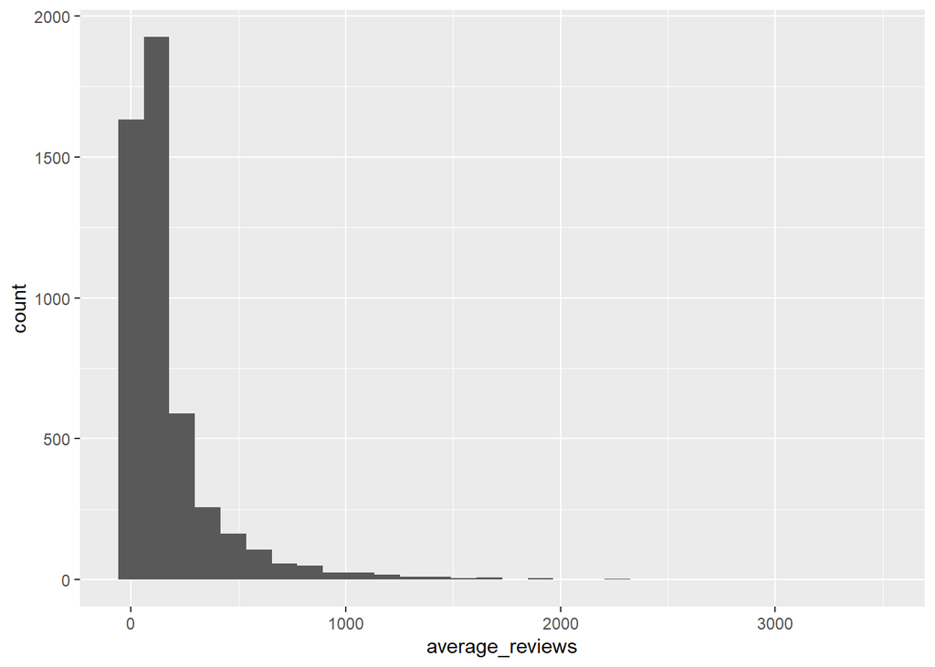

```r
avg_user_reviews<-important_beers %>% group_by(user) %>% summarise(average_reviews=mean(total_user_reviews))
ggplot(avg_user_reviews,aes(x=average_reviews)) + geom_histogram()
```

```r
summary(avg_user_reviews$average_reviews)
```

```
##    Min. 1st Qu.  Median    Mean 3rd Qu.    Max.
##    30.0    50.0    89.0   178.8   198.0  3487.0
```

### So on average each user gives ~180 reviews, but this distribution is very skewed.

### For the full dataset of beers:

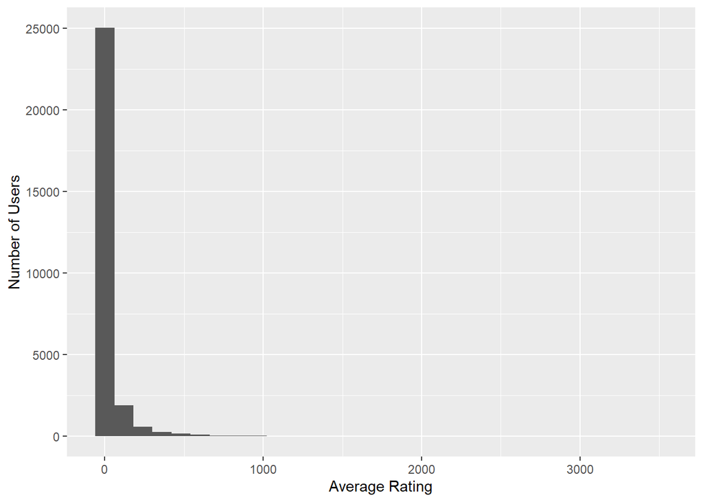

```r
avg_user_ratings_all<-user_reviews_count %>% group_by(user) %>% summarise(average_rating=mean(total_user_reviews))
ggplot(avg_user_ratings_all,aes(x=average_rating)) + geom_histogram() + labs(x="Average Rating", y="Number of Users")
```

```r
summary(avg_user_ratings_all$average_rating)
```

```
##    Min. 1st Qu.  Median    Mean 3rd Qu.    Max.
##    1.00    1.00    3.00   35.07   15.00 3487.00
```

### So on average each user gives 35 reviews, but this distribution is very skewed.